# Mémoire

Degives Nicolas

2023

# 1 Fonction utiles

```r
diameter_outliers <- function(data) {
  Q1 <- quantile(data$diameter, 0.25)
  Q3 <- quantile(data$diameter, 0.75)
  IQR <- Q3 - Q1
  lower <- Q1 - 1.5*IQR
  upper <- Q3 + 1.5*IQR
  data_clean <- data %>% filter(diameter >= lower & diameter <= upper)
  return(data_clean)
}
```

L’intervalle interquartile (IQR) est constitué des 50 % centraux des données et contient la majorité de vos points de données. Dans un diagramme en boîte, l’IQR est la partie de la boîte située entre le premier et le troisième quartile. L’IQR peut être utilisé pour calculer les limites inférieures et supérieures des données, ce qui permet d’identifier les valeurs aberrantes. Les valeurs au dela de Q1-1.5 IQR ou de Q3+1.5 IQR sont enlevée.

# 2 Importation données

aerial reprend les données de l’excel qui synthétise les résultats de parties aériennes du CIPF.  
early.global provient du batch ‘global root data’ exporté de smartroot sur les échantillons de début de culture en rhizotron.  
early.growth provient du batch ‘growth rate’ exporté de smartroot sur les échantillons de début de culture en rhizotron.  
node reprend le nimbre de racine nodale par noeuds des échantillons en fin de culture.  
end.global provient du batch ‘global root data’ exporté de smartroot sur les échantillons de fin de culture du CIPF.  
**!!! Toutes les mesures extraites de SmartRoot sont en cm !!!**

```r
# Load your data here
aerial <- read_excel("Aerials data/Sorgho20_21_22_CIPF.xlsx")
early.global <- read.csv("C:/Nico/Github/Memoire/Early_growth_root_data/early global.csv")
early.growth <- read.csv("C:/Nico/Github/Memoire/Early_growth_root_data/early growth.csv")
node <- read_excel("End_growth_root_data/root_data/0.global_root_data/node.xlsx")
end.global <- data.frame()
for (variete in c("Amiggo","Biggben","Hyperion","Juno","Swingg","Vegga")) {
  paste0("C:/Nico/Github/Memoire/End_growth_root_data/root_data/0.global_root_data/",variete,".csv") %>%
    read.csv() %>%
    mutate(variety = factor(variete)) %>%
    rbind(end.global,.) -> end.global
  }
```

# 3 Préparation et tri des dataframe

## 3.1 Early data

Dataframe avec diamètres de toutes les racines + ratio diamètre
$$\frac{latérale}{primaire}$$
.

```r
early.data <- data.frame()
for (variete in c("Amiggo","Biggben","Hyperion","Juno","Swingg","Vegga")) {
  early.global %>%
    subset(grepl(substr(variete, start = 1, stop = 1),.$image)) %>%
    mutate(variety=factor(variete)) %>%
    select('root_name','root','diameter','root_ontology','parent','parent_name','variety','child_density') %>%
    mutate(parent_diameter = ifelse(parent != '-1', diameter[match(parent, root)],NA)) %>%
    mutate(ratio_diameter = ifelse(parent_name != '-1', diameter/parent_diameter, NA)) %>%
    rbind(early.data,.) -> early.data
}
```

## 3.2 Primary data

Dataframe avec les données de croissance et de diamètre des racines primaires

```r
early.growth %>%
  subset(root_name==' root_0') %>%
  group_by(root) %>%
  na.omit() %>%
  filter(date == max(date)) %>%
  mutate(growth = position/date) %>%
  left_join(., early.data, by = "root") %>%
  select('variety','root','position','date','growth','diameter') -> primary
```

## 3.3 node

```r
node$variety = as.factor(node$variety)
node$plant = as.factor(node$plant)
```

## 3.4 End data

```r
end.global %>%
    select('root_name','root','diameter','root_ontology','parent','parent_name','variety','child_density') %>%
    mutate(parent_diameter = ifelse(parent != '-1', diameter[match(parent, root)],NA)) %>%
    mutate(ratio_diameter = ifelse(parent_name != '-1', diameter/parent_diameter, NA)) -> end.data
```

# 4 Estimation des cinq paramètres

## 4.1 Dmin

### 4.1.1 Data

Prendre, pour chaque nodale, la latérale la plus petite.  
Enlève les outliers par variétés.  
end.data

```r
Dmin <- aggregate(diameter ~ parent+variety+parent_name, data=end.data,FUN=min)
Dmin_clean <- data.frame()
for (variete in c("Amiggo","Biggben","Hyperion","Juno","Swingg","Vegga")) {
  subset(Dmin, variety==variete) %>%
    diameter_outliers(.) %>%
    rbind(Dmin_clean,.) -> Dmin_clean
}
```

### 4.1.2 Stats descriptive

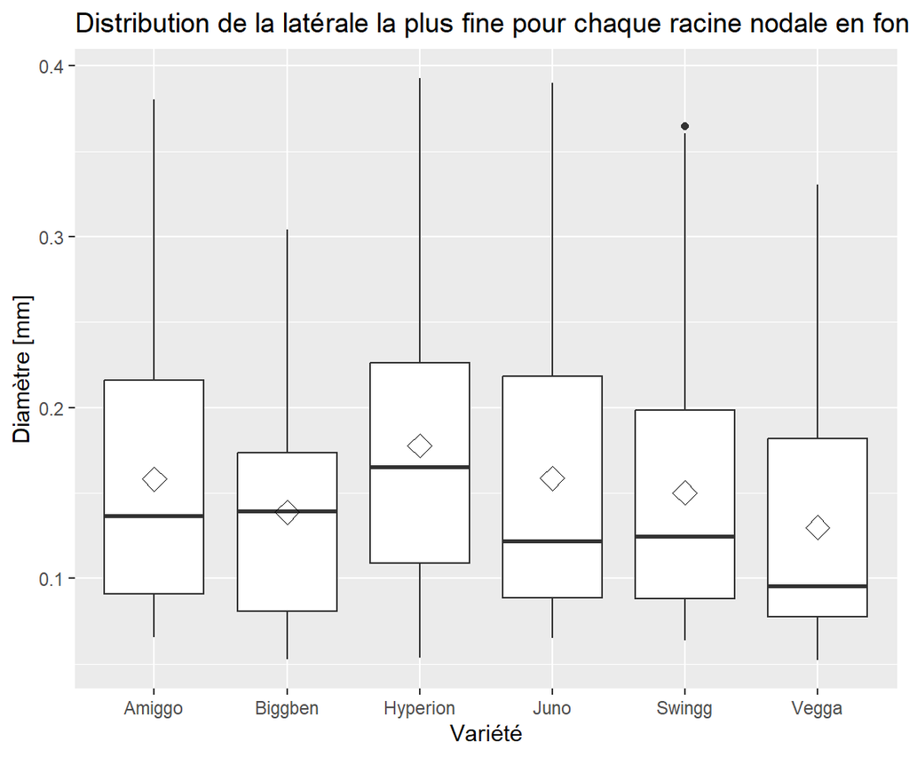

```r
ggplot(data=Dmin_clean, aes(x=variety,y=diameter*10))+
  geom_boxplot()+
  stat_summary(fun=mean, geom="point", shape=23, size=4)+
  labs(title='Distribution de la latérale la plus fine pour chaque racine nodale en fonction de la variété de sorgho',
       x='Variété', y='Diamètre [mm]')+
  theme_gray()
```

### 4.1.3 Modèle

```r
mod_min <- lm(diameter*10 ~ variety, data = Dmin_clean)
pander(summary(mod_min))
```

|  | Estimate | Std. Error | t value | Pr(>\|t\|) |
| --- | --- | --- | --- | --- |
| **(Intercept)** | 0.1581 | 0.009185 | 17.22 | 8.825e-50 |
| **varietyBiggben** | -0.01936 | 0.01352 | -1.432 | 0.1529 |
| **varietyHyperion** | 0.01954 | 0.01286 | 1.52 | 0.1293 |
| **varietyJuno** | 0.0003681 | 0.01304 | 0.02823 | 0.9775 |
| **varietySwingg** | -0.007954 | 0.01319 | -0.6032 | 0.5467 |
| **varietyVegga** | -0.02846 | 0.01371 | -2.076 | 0.0386 |

Fitting linear model: diameter * 10 ~ variety

| Observations | Residual Std. Error | $R^2$ | Adjusted $R^2$ |
| --- | --- | --- | --- |
| 395 | 0.07685 | 0.0385 | 0.02614 |

```r
pander(anova(mod_min))
```

Analysis of Variance Table

|  | Df | Sum Sq | Mean Sq | F value | Pr(>F) |
| --- | --- | --- | --- | --- | --- |
| **variety** | 5 | 0.09198 | 0.0184 | 3.115 | 0.009044 |
| **Residuals** | 389 | 2.297 | 0.005906 | NA | NA |

Observe les distributions et test anova pour voir si similaire/différent.

### 4.1.4 Hypothèse sous-jacente

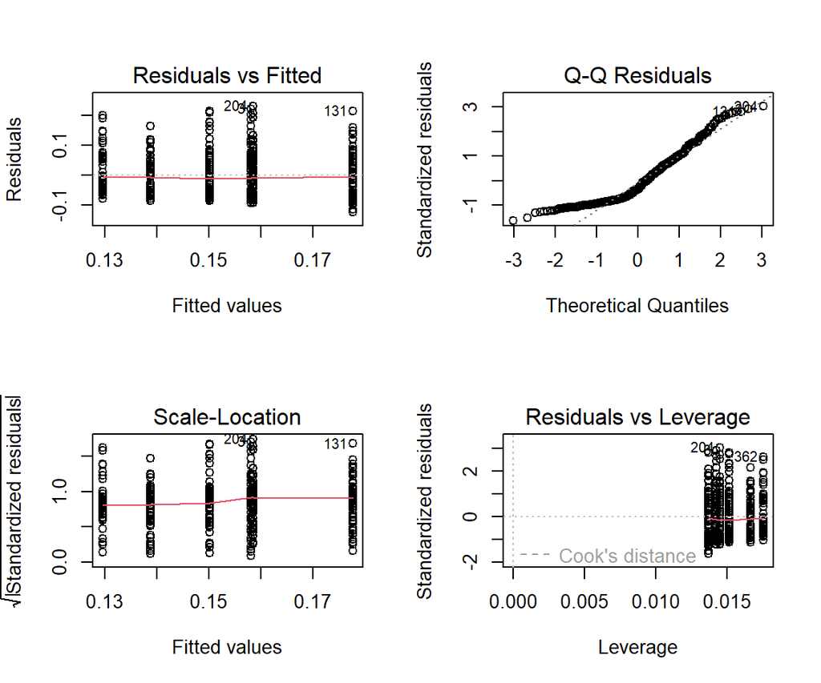

```r
par(mfrow=c(2,2))
plot(mod_min)
```

```r
par(mfrow=c(1,1))
pander(leveneTest(mod_min, center = "median"))
```

Levene’s Test for Homogeneity of Variance (center = “median”)

|  | Df | F value | Pr(>F) |
| --- | --- | --- | --- |
| **group** | 5 | 1.368 | 0.2354 |
|  | 389 | NA | NA |

Test levene pour homogénéité de la variance.

### 4.1.5 Inférence

```r
lsm <- lsmeans(mod_min, pairwise ~ variety)
pander(summary(lsm))
```

- **lsmeans**:

  | variety | lsmean | SE | df | lower.CL | upper.CL |
  | --- | --- | --- | --- | --- | --- |
  | Amiggo | 0.1581 | 0.009185 | 389 | 0.1401 | 0.1762 |
  | Biggben | 0.1388 | 0.009921 | 389 | 0.1193 | 0.1583 |
  | Hyperion | 0.1777 | 0.008995 | 389 | 0.16 | 0.1954 |
  | Juno | 0.1585 | 0.009252 | 389 | 0.1403 | 0.1767 |
  | Swingg | 0.1502 | 0.00946 | 389 | 0.1316 | 0.1688 |
  | Vegga | 0.1297 | 0.01018 | 389 | 0.1097 | 0.1497 |

- **contrasts**:

  | contrast | estimate | SE | df | t.ratio | p.value |
  | --- | --- | --- | --- | --- | --- |
  | Amiggo - Biggben | 0.01936 | 0.01352 | 389 | 1.432 | 0.7075 |
  | Amiggo - Hyperion | -0.01954 | 0.01286 | 389 | -1.52 | 0.6516 |
  | Amiggo - Juno | -0.0003681 | 0.01304 | 389 | -0.02823 | 1 |
  | Amiggo - Swingg | 0.007954 | 0.01319 | 389 | 0.6032 | 0.9908 |
  | Amiggo - Vegga | 0.02846 | 0.01371 | 389 | 2.076 | 0.3023 |
  | Biggben - Hyperion | -0.0389 | 0.01339 | 389 | -2.905 | 0.04459 |
  | Biggben - Juno | -0.01973 | 0.01357 | 389 | -1.454 | 0.6935 |
  | Biggben - Swingg | -0.01141 | 0.01371 | 389 | -0.8322 | 0.9614 |
  | Biggben - Vegga | 0.009096 | 0.01421 | 389 | 0.6399 | 0.9879 |
  | Hyperion - Juno | 0.01917 | 0.0129 | 389 | 1.486 | 0.6735 |
  | Hyperion - Swingg | 0.0275 | 0.01305 | 389 | 2.106 | 0.2861 |
  | Hyperion - Vegga | 0.048 | 0.01358 | 389 | 3.534 | 0.006082 |
  | Juno - Swingg | 0.008322 | 0.01323 | 389 | 0.6289 | 0.9888 |
  | Juno - Vegga | 0.02883 | 0.01376 | 389 | 2.096 | 0.2917 |
  | Swingg - Vegga | 0.0205 | 0.0139 | 389 | 1.475 | 0.6802 |

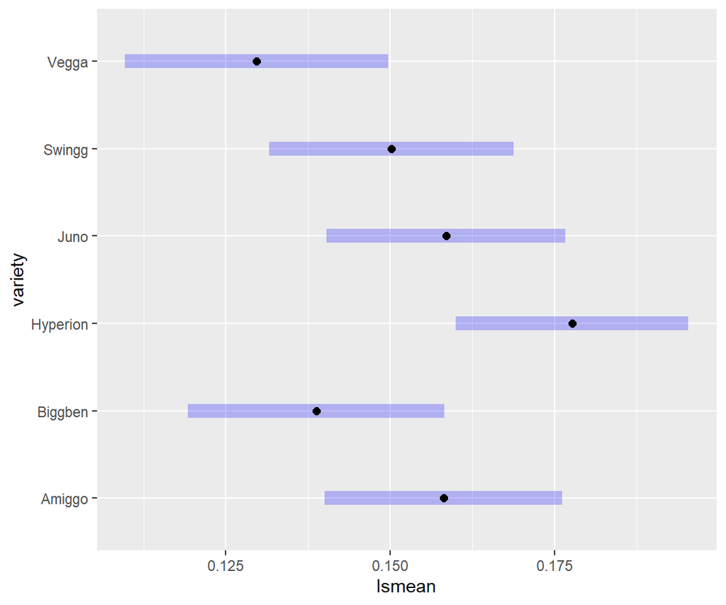

```r
plot(lsm)
```

```r
paste('La moyenne de toute les variétés sauf Vegga =',
      mean(subset(Dmin_clean,!(variety=='Vegga'))$diameter)*10)
```

```
## [1] "La moyenne de toute les variétés sauf Vegga = 0.157434736689349"
```

Récupère la moyenne des distributions de Dmin pour estimer le paramètre.  
Méthode Tukey pour l’ajustement de p-valeur.

## 4.2 Dmax

Regarde les distributions de diamètres des racines nodales.

### 4.2.1 Data

```r
nodal_clean <- subset(end.data, root_ontology==" Root") %>%
  diameter_outliers(.)
```

### 4.2.2 Stat descriptive

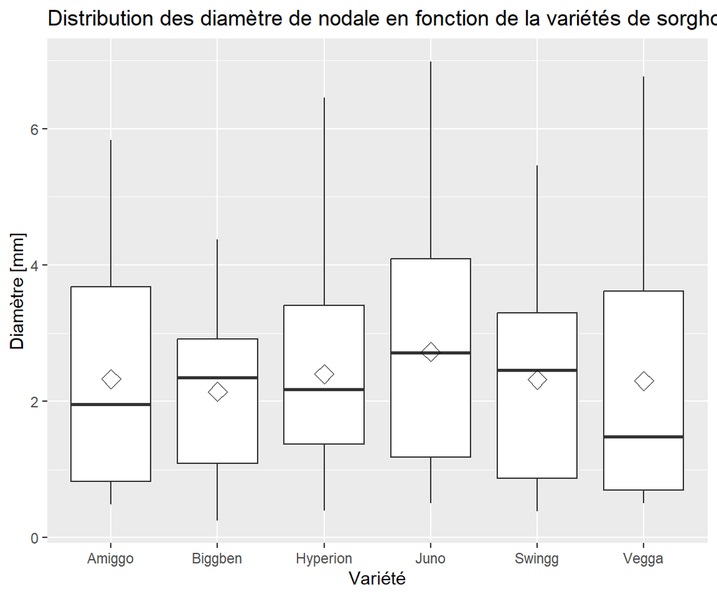

```r
nodal_clean %>%
  ggplot(aes(x=variety,y=diameter*10))+
  geom_boxplot()+
  stat_summary(fun=mean, geom="point", shape=23, size=4)+
  labs(title='Distribution des diamètre de nodale en fonction de la variétés de sorgho',
       x='Variété', y='Diamètre [mm]')+
  theme_gray()
```

### 4.2.3 Modèle

```r
mod_max <- lm(diameter*10 ~ variety, data=nodal_clean)
pander(summary(mod_max))
```

|  | Estimate | Std. Error | t value | Pr(>\|t\|) |
| --- | --- | --- | --- | --- |
| **(Intercept)** | 2.326 | 0.1795 | 12.96 | 2.336e-32 |
| **varietyBiggben** | -0.1873 | 0.2608 | -0.7181 | 0.4731 |
| **varietyHyperion** | 0.07554 | 0.2488 | 0.3036 | 0.7616 |
| **varietyJuno** | 0.3987 | 0.2496 | 1.598 | 0.1109 |
| **varietySwingg** | -0.007416 | 0.2576 | -0.02879 | 0.977 |
| **varietyVegga** | -0.0273 | 0.2654 | -0.1029 | 0.9181 |

Fitting linear model: diameter * 10 ~ variety

| Observations | Residual Std. Error | $R^2$ | Adjusted $R^2$ |
| --- | --- | --- | --- |
| 409 | 1.502 | 0.01459 | 0.002364 |

```r
pander(anova(mod_max))
```

Analysis of Variance Table

|  | Df | Sum Sq | Mean Sq | F value | Pr(>F) |
| --- | --- | --- | --- | --- | --- |
| **variety** | 5 | 13.45 | 2.691 | 1.193 | 0.3116 |
| **Residuals** | 403 | 908.7 | 2.255 | NA | NA |

### 4.2.4 Hypothèse

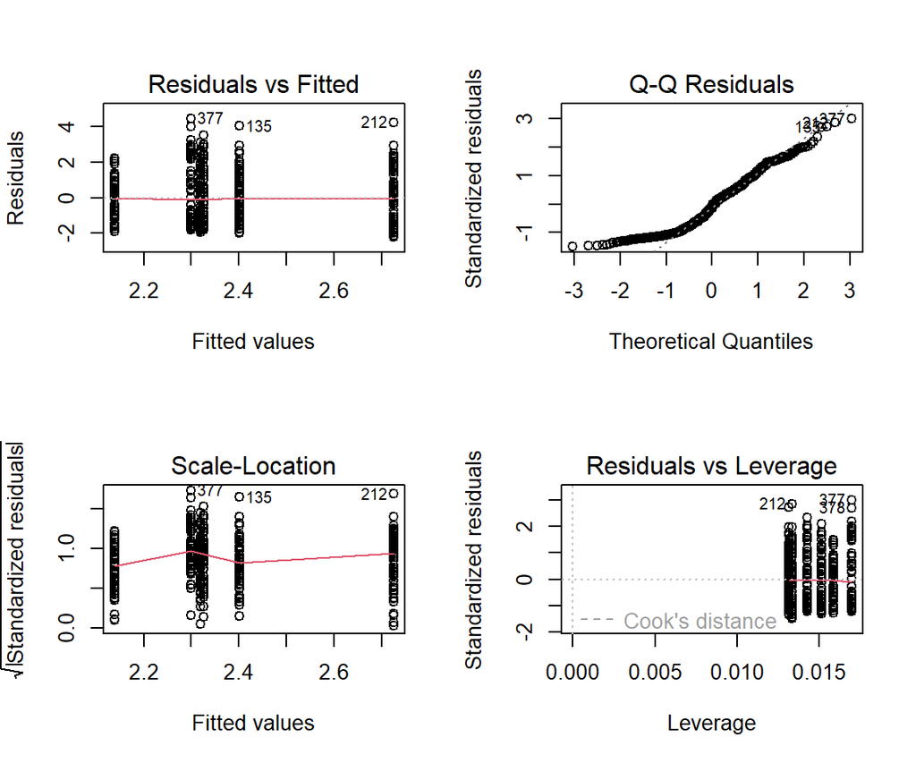

```r
par(mfrow = c(2,2))
plot(mod_max)
```

```r
par(mfrow = c(1,1))
pander(leveneTest(mod_max, center = "median"))
```

Levene’s Test for Homogeneity of Variance (center = “median”)

|  | Df | F value | Pr(>F) |
| --- | --- | --- | --- |
| **group** | 5 | 2.939 | 0.0128 |
|  | 403 | NA | NA |

### 4.2.5 Inférence

```r
lsm <- lsmeans(mod_max, pairwise ~ variety)
pander(summary(lsm))
```

- **lsmeans**:

  | variety | lsmean | SE | df | lower.CL | upper.CL |
  | --- | --- | --- | --- | --- | --- |
  | Amiggo | 2.326 | 0.1795 | 403 | 1.974 | 2.679 |
  | Biggben | 2.139 | 0.1892 | 403 | 1.767 | 2.511 |
  | Hyperion | 2.402 | 0.1722 | 403 | 2.063 | 2.741 |
  | Juno | 2.725 | 0.1734 | 403 | 2.384 | 3.066 |
  | Swingg | 2.319 | 0.1848 | 403 | 1.956 | 2.682 |
  | Vegga | 2.299 | 0.1955 | 403 | 1.915 | 2.683 |

- **contrasts**:

  | contrast | estimate | SE | df | t.ratio | p.value |
  | --- | --- | --- | --- | --- | --- |
  | Amiggo - Biggben | 0.1873 | 0.2608 | 403 | 0.7181 | 0.9797 |
  | Amiggo - Hyperion | -0.07554 | 0.2488 | 403 | -0.3036 | 0.9997 |
  | Amiggo - Juno | -0.3987 | 0.2496 | 403 | -1.598 | 0.6007 |
  | Amiggo - Swingg | 0.007416 | 0.2576 | 403 | 0.02879 | 1 |
  | Amiggo - Vegga | 0.0273 | 0.2654 | 403 | 0.1029 | 1 |
  | Biggben - Hyperion | -0.2628 | 0.2559 | 403 | -1.027 | 0.9087 |
  | Biggben - Juno | -0.5859 | 0.2566 | 403 | -2.283 | 0.2033 |
  | Biggben - Swingg | -0.1799 | 0.2645 | 403 | -0.68 | 0.9841 |
  | Biggben - Vegga | -0.16 | 0.2721 | 403 | -0.588 | 0.9918 |
  | Hyperion - Juno | -0.3231 | 0.2444 | 403 | -1.322 | 0.7727 |
  | Hyperion - Swingg | 0.08295 | 0.2527 | 403 | 0.3283 | 0.9995 |
  | Hyperion - Vegga | 0.1028 | 0.2606 | 403 | 0.3947 | 0.9988 |
  | Juno - Swingg | 0.4061 | 0.2534 | 403 | 1.602 | 0.5975 |
  | Juno - Vegga | 0.426 | 0.2613 | 403 | 1.63 | 0.579 |
  | Swingg - Vegga | 0.01988 | 0.269 | 403 | 0.0739 | 1 |

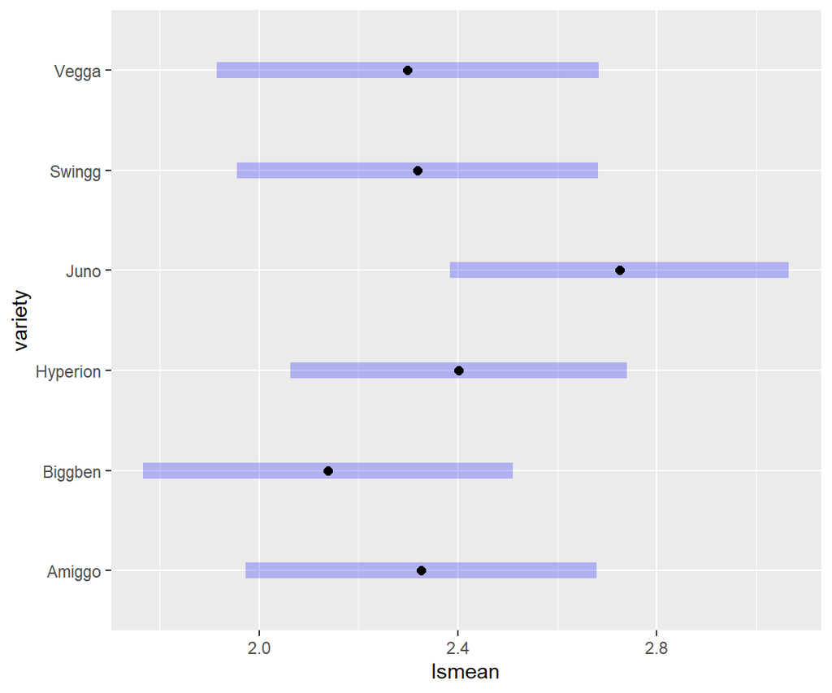

```r
plot(lsm)
```

```r
Dmax <- max(nodal_clean$diameter)*10
paste('Le Dmax global pour les six variétés est',Dmax)
```

```
## [1] "Le Dmax global pour les six variétés est 6.984537"
```

Voir similitude ou différence sur base de distribution et modèle anova.  
Récupère les plus gros diamètres.  
Dmax correspond au diamètre maximum de la distribution des racines nodales observées.

## 4.3 Drange

Drange, la range relative de diamètre, est calculé avec les diamètre extrême comme :
$$2*\frac{D_{max}-D_{min}}{D_{max}+D_{min}}$$
.
Le Drange est mesuré pour chaque racine nodale avec Dmex le diamètre de la nodale et Dmin le diamètre de sa latérale la plus fine.

### 4.3.1 Data

```r
Drange <- aggregate(diameter ~ parent+variety+parent_name+parent_diameter, data=end.data,FUN=min) %>%
  mutate(Drange=2*(parent_diameter-diameter)/(parent_diameter+diameter))

Drange_clean <- data.frame()
for (variete in c("Amiggo","Biggben","Hyperion","Juno","Swingg","Vegga")) {
  subset(Drange, variety==variete) %>%
    diameter_outliers(.) %>%
    rbind(Drange_clean,.) -> Drange_clean
}
```

### 4.3.2 Stats descriptive

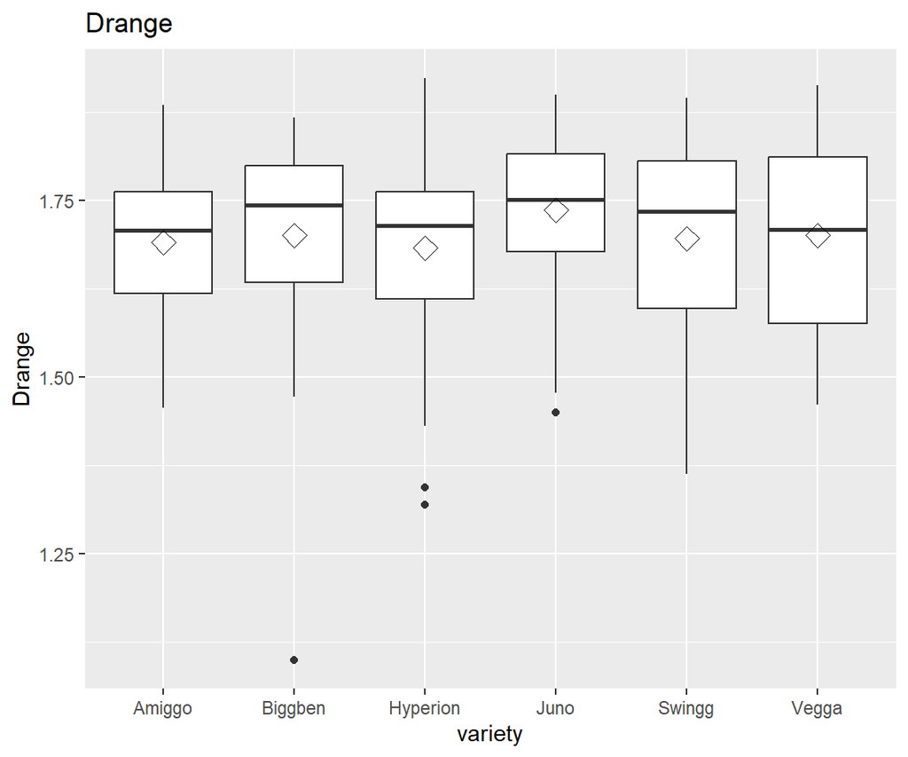

```r
Drange_clean %>%
  ggplot(aes(x=variety,y=Drange))+
  geom_boxplot()+
  stat_summary(fun=mean, geom="point", shape=23, size=4)+
  labs(title='Drange')+
  theme_gray()
```

### 4.3.3 Modèle

```r
mod_range <- lm(Drange ~ variety, data=Drange_clean)
pander(summary(mod_range))
```

|  | Estimate | Std. Error | t value | Pr(>\|t\|) |
| --- | --- | --- | --- | --- |
| **(Intercept)** | 1.691 | 0.01478 | 114.4 | 7.72e-300 |
| **varietyBiggben** | 0.01025 | 0.02186 | 0.469 | 0.6394 |
| **varietyHyperion** | -0.007652 | 0.02076 | -0.3686 | 0.7126 |
| **varietyJuno** | 0.04585 | 0.02098 | 2.185 | 0.02946 |
| **varietySwingg** | 0.005607 | 0.0213 | 0.2632 | 0.7925 |
| **varietyVegga** | 0.009969 | 0.02206 | 0.4518 | 0.6517 |

Fitting linear model: Drange ~ variety

| Observations | Residual Std. Error | $R^2$ | Adjusted $R^2$ |
| --- | --- | --- | --- |
| 392 | 0.1237 | 0.0198 | 0.007101 |

```r
pander(anova(mod_range))
```

Analysis of Variance Table

|  | Df | Sum Sq | Mean Sq | F value | Pr(>F) |
| --- | --- | --- | --- | --- | --- |
| **variety** | 5 | 0.1192 | 0.02385 | 1.559 | 0.1706 |
| **Residuals** | 386 | 5.904 | 0.01529 | NA | NA |

### 4.3.4 Hypothèse

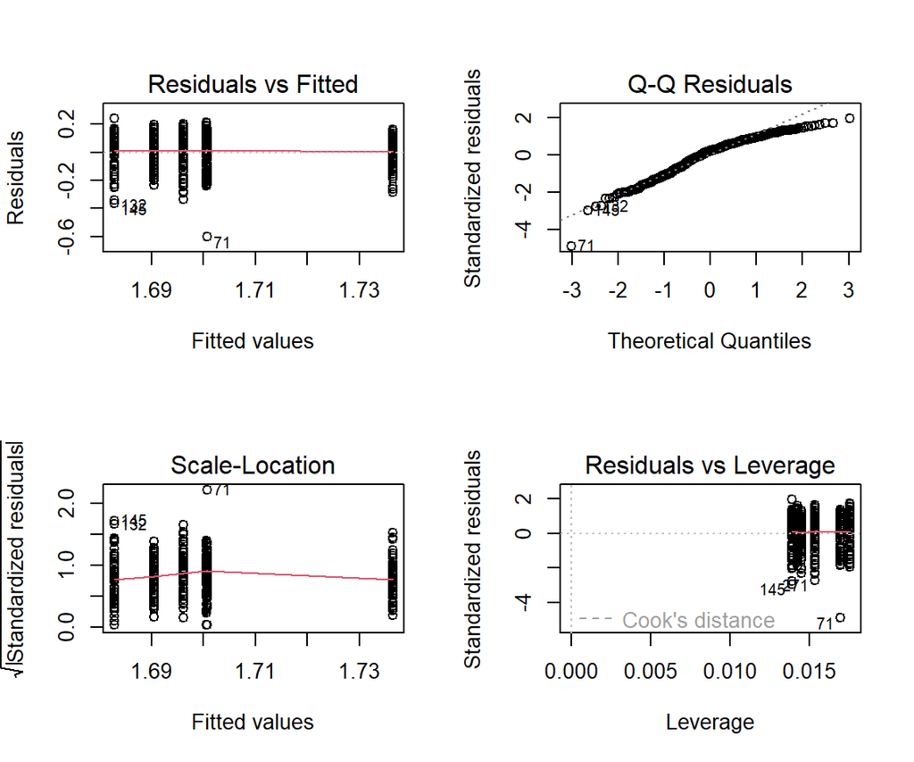

```r
par(mfrow = c(2,2))
plot(mod_range)
```

```r
par(mfrow = c(1,1))
pander(leveneTest(mod_range, center = "median"))
```

Levene’s Test for Homogeneity of Variance (center = “median”)

|  | Df | F value | Pr(>F) |
| --- | --- | --- | --- |
| **group** | 5 | 2.014 | 0.07583 |
|  | 386 | NA | NA |

### 4.3.5 Inférence

```r
lsm <- lsmeans(mod_range, pairwise ~ variety)
pander(summary(lsm))
```

- **lsmeans**:

  | variety | lsmean | SE | df | lower.CL | upper.CL |
  | --- | --- | --- | --- | --- | --- |
  | Amiggo | 1.691 | 0.01478 | 386 | 1.661 | 1.72 |
  | Biggben | 1.701 | 0.0161 | 386 | 1.669 | 1.732 |
  | Hyperion | 1.683 | 0.01457 | 386 | 1.654 | 1.712 |
  | Juno | 1.736 | 0.01489 | 386 | 1.707 | 1.766 |
  | Swingg | 1.696 | 0.01534 | 386 | 1.666 | 1.726 |
  | Vegga | 1.7 | 0.01638 | 386 | 1.668 | 1.733 |

- **contrasts**:

  | contrast | estimate | SE | df | t.ratio | p.value |
  | --- | --- | --- | --- | --- | --- |
  | Amiggo - Biggben | -0.01025 | 0.02186 | 386 | -0.469 | 0.9972 |
  | Amiggo - Hyperion | 0.007652 | 0.02076 | 386 | 0.3686 | 0.9991 |
  | Amiggo - Juno | -0.04585 | 0.02098 | 386 | -2.185 | 0.2469 |
  | Amiggo - Swingg | -0.005607 | 0.0213 | 386 | -0.2632 | 0.9998 |
  | Amiggo - Vegga | -0.009969 | 0.02206 | 386 | -0.4518 | 0.9976 |
  | Biggben - Hyperion | 0.0179 | 0.02172 | 386 | 0.8243 | 0.9629 |
  | Biggben - Juno | -0.0356 | 0.02193 | 386 | -1.623 | 0.5835 |
  | Biggben - Swingg | 0.004643 | 0.02224 | 386 | 0.2088 | 0.9999 |
  | Biggben - Vegga | 0.0002812 | 0.02297 | 386 | 0.01224 | 1 |
  | Hyperion - Juno | -0.0535 | 0.02083 | 386 | -2.568 | 0.1078 |
  | Hyperion - Swingg | -0.01326 | 0.02116 | 386 | -0.6266 | 0.989 |
  | Hyperion - Vegga | -0.01762 | 0.02193 | 386 | -0.8037 | 0.9668 |
  | Juno - Swingg | 0.04024 | 0.02138 | 386 | 1.883 | 0.4144 |
  | Juno - Vegga | 0.03588 | 0.02214 | 386 | 1.621 | 0.5851 |
  | Swingg - Vegga | -0.004362 | 0.02244 | 386 | -0.1944 | 1 |

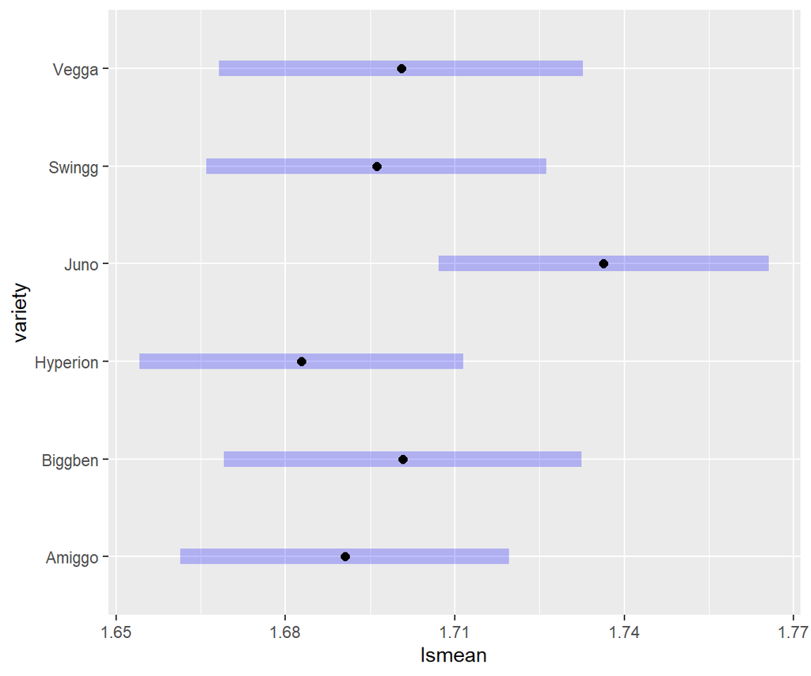

```r
plot(lsm)
```

```r
paste('La moyenne de toute les variétés =',
      mean(Drange_clean$Drange))
```

```
## [1] "La moyenne de toute les variétés = 1.70108902770793"
```

## 4.4 IBD : inter-branch distance

IBD est calculé comme la valeur moyenne de la distance entre latérales voisines.  
Sur early data parce que tendu de tout voir sur fin de culture.

### 4.4.1 Data

```r
branching <- early.data %>%
  subset(root_name==' root_0') %>%
  mutate(IBD=1/child_density)
```

### 4.4.2 Stats descriptive

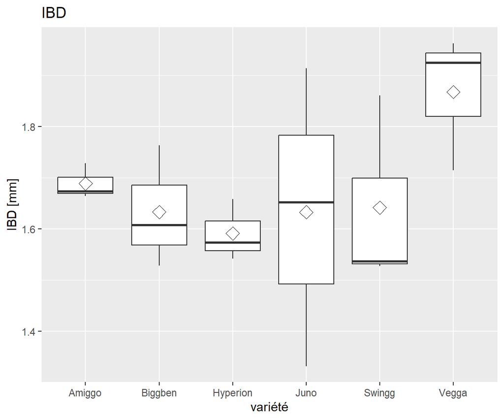

```r
branching %>%
  ggplot(aes(x=variety,y=IBD*10))+
  geom_boxplot()+
  stat_summary(fun=mean, geom="point", shape=23, size=4)+
  labs(title='IBD',x='variété',y='IBD [mm]')+
  theme_gray()
```

### 4.4.3 Modèle

```r
mod_IBD <- lm(IBD*10 ~ variety, data=branching)
pander(summary(mod_IBD))
```

|  | Estimate | Std. Error | t value | Pr(>\|t\|) |
| --- | --- | --- | --- | --- |
| **(Intercept)** | 1.689 | 0.09361 | 18.04 | 4.631e-10 |
| **varietyBiggben** | -0.05531 | 0.1324 | -0.4178 | 0.6835 |
| **varietyHyperion** | -0.09739 | 0.1324 | -0.7357 | 0.4761 |
| **varietyJuno** | -0.05593 | 0.1324 | -0.4224 | 0.6802 |
| **varietySwingg** | -0.04694 | 0.1324 | -0.3545 | 0.7291 |
| **varietyVegga** | 0.1789 | 0.1324 | 1.351 | 0.2015 |

Fitting linear model: IBD * 10 ~ variety

| Observations | Residual Std. Error | $R^2$ | Adjusted $R^2$ |
| --- | --- | --- | --- |
| 18 | 0.1621 | 0.3174 | 0.03304 |

```r
pander(anova(mod_IBD))
```

Analysis of Variance Table

|  | Df | Sum Sq | Mean Sq | F value | Pr(>F) |
| --- | --- | --- | --- | --- | --- |
| **variety** | 5 | 0.1467 | 0.02935 | 1.116 | 0.4023 |
| **Residuals** | 12 | 0.3155 | 0.02629 | NA | NA |

### 4.4.4 Hypothèse

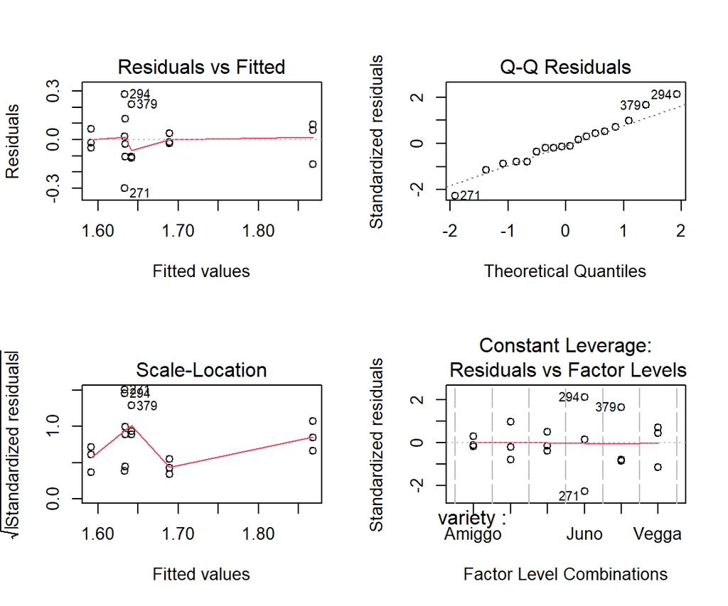

```r
par(mfrow = c(2,2))
plot(mod_IBD)
```

```r
par(mfrow = c(1,1))
pander(leveneTest(mod_IBD, center = "median"))
```

Levene’s Test for Homogeneity of Variance (center = “median”)

|  | Df | F value | Pr(>F) |
| --- | --- | --- | --- |
| **group** | 5 | 0.8004 | 0.5703 |
|  | 12 | NA | NA |

### 4.4.5 Inférence

```r
lsm <- lsmeans(mod_IBD, pairwise ~ variety)
pander(summary(lsm))
```

- **lsmeans**:

  | variety | lsmean | SE | df | lower.CL | upper.CL |
  | --- | --- | --- | --- | --- | --- |
  | Amiggo | 1.689 | 0.09361 | 12 | 1.485 | 1.893 |
  | Biggben | 1.634 | 0.09361 | 12 | 1.43 | 1.838 |
  | Hyperion | 1.591 | 0.09361 | 12 | 1.388 | 1.795 |
  | Juno | 1.633 | 0.09361 | 12 | 1.429 | 1.837 |
  | Swingg | 1.642 | 0.09361 | 12 | 1.438 | 1.846 |
  | Vegga | 1.868 | 0.09361 | 12 | 1.664 | 2.072 |

- **contrasts**:

  | contrast | estimate | SE | df | t.ratio | p.value |
  | --- | --- | --- | --- | --- | --- |
  | Amiggo - Biggben | 0.05531 | 0.1324 | 12 | 0.4178 | 0.9979 |
  | Amiggo - Hyperion | 0.09739 | 0.1324 | 12 | 0.7357 | 0.9733 |
  | Amiggo - Juno | 0.05593 | 0.1324 | 12 | 0.4224 | 0.9978 |
  | Amiggo - Swingg | 0.04694 | 0.1324 | 12 | 0.3545 | 0.9991 |
  | Amiggo - Vegga | -0.1789 | 0.1324 | 12 | -1.351 | 0.753 |
  | Biggben - Hyperion | 0.04208 | 0.1324 | 12 | 0.3179 | 0.9994 |
  | Biggben - Juno | 0.0006167 | 0.1324 | 12 | 0.004658 | 1 |
  | Biggben - Swingg | -0.008373 | 0.1324 | 12 | -0.06324 | 1 |
  | Biggben - Vegga | -0.2342 | 0.1324 | 12 | -1.769 | 0.5172 |
  | Hyperion - Juno | -0.04147 | 0.1324 | 12 | -0.3132 | 0.9995 |
  | Hyperion - Swingg | -0.05046 | 0.1324 | 12 | -0.3811 | 0.9987 |
  | Hyperion - Vegga | -0.2763 | 0.1324 | 12 | -2.087 | 0.3541 |
  | Juno - Swingg | -0.008989 | 0.1324 | 12 | -0.0679 | 1 |
  | Juno - Vegga | -0.2348 | 0.1324 | 12 | -1.774 | 0.5146 |
  | Swingg - Vegga | -0.2259 | 0.1324 | 12 | -1.706 | 0.5527 |

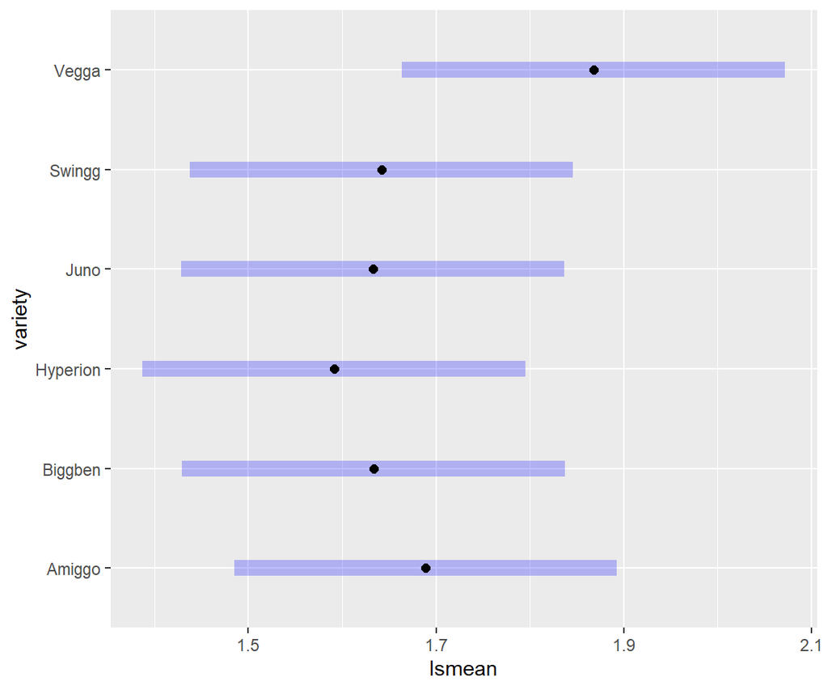

```r
plot(lsm)
```

```r
hypothesis <- list("Amiggo - Vegga = 0" = c(1,0,0,0,0,-1),
                   "Biggben - Vegga = 0" = c(0,1,0,0,0,-1),
                   "Hyperion - Vegga = 0" = c(0,0,1,0,0,-1),
                   "Juno - Vegga = 0" = c(0,0,0,1,0,-1),
                   "Swingg - Vegga = 0" = c(0,0,0,0,1,-1))
contrast(lsm$lsmeans, hypothesis)
```

```
##  contrast             estimate    SE df t.ratio p.value
##  Amiggo - Vegga = 0     -0.179 0.132 12  -1.351  0.2015
##  Biggben - Vegga = 0    -0.234 0.132 12  -1.769  0.1022
##  Hyperion - Vegga = 0   -0.276 0.132 12  -2.087  0.0589
##  Juno - Vegga = 0       -0.235 0.132 12  -1.774  0.1014
##  Swingg - Vegga = 0     -0.226 0.132 12  -1.706  0.1137
```

```r
paste('IBD moyen pour les six variété =',mean(branching$IBD)*10)
```

```
## [1] "IBD moyen pour les six variété = 1.67609582776916"
```

## 4.5 DIDm

Pente de la régression linéaire du diamètre des racines latérales vs. leur racine mère.

### 4.5.1 Data

```r
lateral.clean <- data.frame()
for (variete in c("Amiggo","Biggben","Hyperion","Juno","Swingg","Vegga")) {
  filter(end.data, variety==variete,root_ontology==' Lateral root') %>%
    mutate(diameter=diameter*10) %>%
    mutate(parent_diameter=parent_diameter*10) %>%
    diameter_outliers(.) %>%
    rbind(lateral.clean,.) -> lateral.clean
}
```

### 4.5.2 Stats descriptive

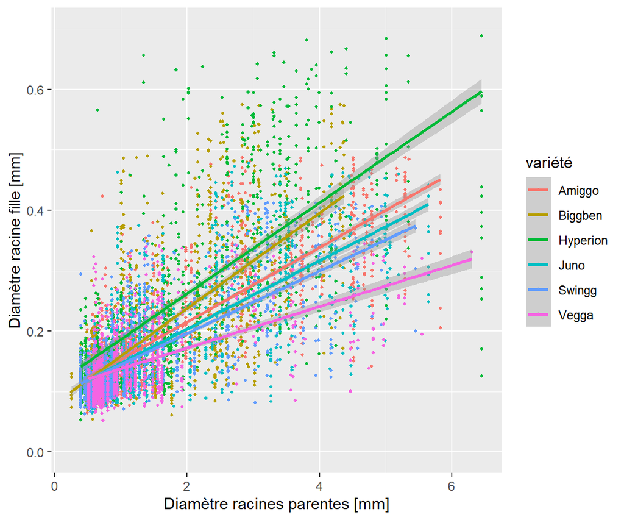

```r
lateral.clean %>%
  ggplot(aes(x=parent_diameter,y=diameter,col=variety))+
  geom_point(size=0.8)+
  geom_smooth(method = "lm")+
  labs(x='Diamètre racines parentes [mm]',y='Diamètre racine fille [mm]',col='variété')+
  scale_y_continuous(limits = c(0,0.7))
```

### 4.5.3 Modèle

```r
mod_DIDm <- lm(diameter~variety*parent_diameter ,data=lateral.clean)
pander(summary(mod_DIDm))
```

Table continues below

|  | Estimate | Std. Error | t value |
| --- | --- | --- | --- |
| **(Intercept)** | 0.0923 | 0.002619 | 35.25 |
| **varietyBiggben** | -0.01174 | 0.004434 | -2.647 |
| **varietyHyperion** | 0.01957 | 0.004557 | 4.294 |
| **varietyJuno** | -0.001526 | 0.004087 | -0.3733 |
| **varietySwingg** | 0.001062 | 0.004101 | 0.2589 |
| **varietyVegga** | 0.01156 | 0.004209 | 2.747 |
| **parent_diameter** | 0.06157 | 0.001302 | 47.29 |
| **varietyBiggben:parent_diameter** | 0.01714 | 0.002285 | 7.501 |
| **varietyHyperion:parent_diameter** | 0.01361 | 0.002009 | 6.775 |
| **varietyJuno:parent_diameter** | -0.005151 | 0.001985 | -2.595 |
| **varietySwingg:parent_diameter** | -0.01003 | 0.002205 | -4.548 |
| **varietyVegga:parent_diameter** | -0.02737 | 0.002561 | -10.69 |

|  | Pr(>\|t\|) |
| --- | --- |
| **(Intercept)** | 7.841e-252 |
| **varietyBiggben** | 0.008132 |
| **varietyHyperion** | 1.778e-05 |
| **varietyJuno** | 0.709 |
| **varietySwingg** | 0.7957 |
| **varietyVegga** | 0.006032 |
| **parent_diameter** | 0 |
| **varietyBiggben:parent_diameter** | 7.08e-14 |
| **varietyHyperion:parent_diameter** | 1.337e-11 |
| **varietyJuno:parent_diameter** | 0.009476 |
| **varietySwingg:parent_diameter** | 5.51e-06 |
| **varietyVegga:parent_diameter** | 1.805e-26 |

Fitting linear model: diameter ~ variety * parent_diameter

| Observations | Residual Std. Error | $R^2$ | Adjusted $R^2$ |
| --- | --- | --- | --- |
| 7464 | 0.06925 | 0.592 | 0.5914 |

```r
pander(anova(mod_DIDm))
```

Analysis of Variance Table

|  | Df | Sum Sq | Mean Sq | F value | Pr(>F) |
| --- | --- | --- | --- | --- | --- |
| **variety** | 5 | 9.162 | 1.832 | 382 | 0 |
| **parent_diameter** | 1 | 40.98 | 40.98 | 8544 | 0 |
| **variety:parent_diameter** | 5 | 1.726 | 0.3453 | 71.99 | 7.995e-74 |
| **Residuals** | 7452 | 35.74 | 0.004796 | NA | NA |

```r
pander(summary(lm(diameter~parent_diameter,data=subset(lateral.clean,variety=='Biggben'))))
```

|  | Estimate | Std. Error | t value | Pr(>\|t\|) |
| --- | --- | --- | --- | --- |
| **(Intercept)** | 0.08057 | 0.004456 | 18.08 | 1.696e-64 |
| **parent_diameter** | 0.07871 | 0.002339 | 33.65 | 2.633e-173 |

Fitting linear model: diameter ~ parent_diameter

| Observations | Residual Std. Error | $R^2$ | Adjusted $R^2$ |
| --- | --- | --- | --- |
| 1150 | 0.08626 | 0.4966 | 0.4962 |

### 4.5.4 Hypothèse

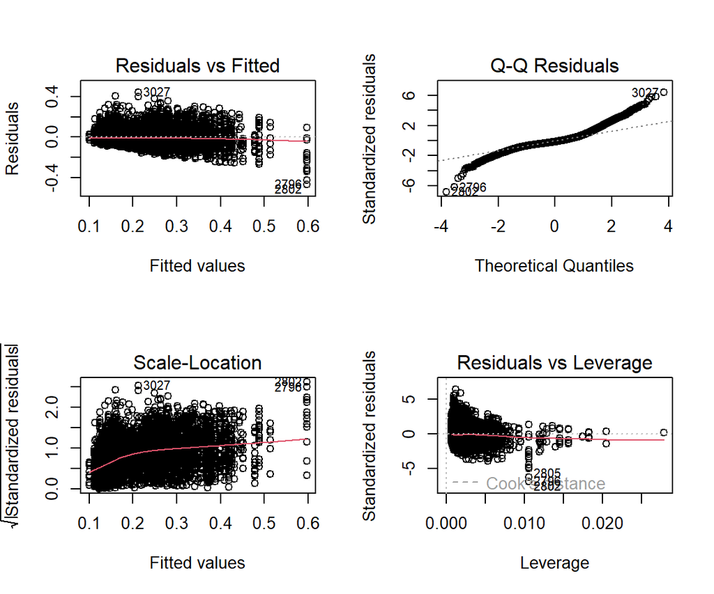

```r
par(mfrow=c(2,2))
plot(mod_DIDm)
```

```r
par(mfrow=c(1,1))
```

### 4.5.5 Inférene

Comparaison des variétés 2 à 2

```r
lsm <- emmeans(mod_DIDm, pairwise ~ variety)
```

```
## NOTE: Results may be misleading due to involvement in interactions
```

```r
pander(summary(lsm))
```

- **emmeans**:

  | variety | emmean | SE | df | lower.CL | upper.CL |
  | --- | --- | --- | --- | --- | --- |
  | Amiggo | 0.1874 | 0.001716 | 7452 | 0.184 | 0.1908 |
  | Biggben | 0.2022 | 0.002043 | 7452 | 0.1981 | 0.2062 |
  | Hyperion | 0.228 | 0.00223 | 7452 | 0.2236 | 0.2324 |
  | Juno | 0.1779 | 0.001907 | 7452 | 0.1742 | 0.1817 |
  | Swingg | 0.173 | 0.00204 | 7452 | 0.169 | 0.177 |
  | Vegga | 0.1567 | 0.002259 | 7452 | 0.1523 | 0.1611 |

- **contrasts**:

  | contrast | estimate | SE | df | t.ratio | p.value |
  | --- | --- | --- | --- | --- | --- |
  | Amiggo - Biggben | -0.01474 | 0.002667 | 7452 | -5.525 | 5.086e-07 |
  | Amiggo - Hyperion | -0.04059 | 0.002814 | 7452 | -14.43 | 1.321e-11 |
  | Amiggo - Juno | 0.009482 | 0.002565 | 7452 | 3.696 | 0.003017 |
  | Amiggo - Swingg | 0.01443 | 0.002665 | 7452 | 5.415 | 9.452e-07 |
  | Amiggo - Vegga | 0.03073 | 0.002837 | 7452 | 10.83 | 1.327e-11 |
  | Biggben - Hyperion | -0.02585 | 0.003024 | 7452 | -8.549 | 1.326e-11 |
  | Biggben - Juno | 0.02422 | 0.002794 | 7452 | 8.667 | 1.326e-11 |
  | Biggben - Swingg | 0.02917 | 0.002887 | 7452 | 10.11 | 1.327e-11 |
  | Biggben - Vegga | 0.04546 | 0.003045 | 7452 | 14.93 | 1.321e-11 |
  | Hyperion - Juno | 0.05007 | 0.002935 | 7452 | 17.06 | 1.321e-11 |
  | Hyperion - Swingg | 0.05502 | 0.003022 | 7452 | 18.21 | 1.321e-11 |
  | Hyperion - Vegga | 0.07132 | 0.003174 | 7452 | 22.47 | 1.321e-11 |
  | Juno - Swingg | 0.00495 | 0.002792 | 7452 | 1.773 | 0.4837 |
  | Juno - Vegga | 0.02124 | 0.002956 | 7452 | 7.186 | 2.424e-11 |
  | Swingg - Vegga | 0.01629 | 0.003044 | 7452 | 5.354 | 1.324e-06 |

Comparaison 2 à 2 des pentes

```r
emtrends(mod_DIDm, pairwise ~ variety, var='parent_diameter')
```

```
## $emtrends
##  variety  parent_diameter.trend      SE   df lower.CL upper.CL
##  Amiggo                  0.0616 0.00130 7452   0.0590   0.0641
##  Biggben                 0.0787 0.00188 7452   0.0750   0.0824
##  Hyperion                0.0752 0.00153 7452   0.0722   0.0782
##  Juno                    0.0564 0.00150 7452   0.0535   0.0594
##  Swingg                  0.0515 0.00178 7452   0.0480   0.0550
##  Vegga                   0.0342 0.00221 7452   0.0299   0.0385
##
## Confidence level used: 0.95
##
## $contrasts
##  contrast           estimate      SE   df t.ratio p.value
##  Amiggo - Biggben   -0.01714 0.00228 7452  -7.501  <.0001
##  Amiggo - Hyperion  -0.01361 0.00201 7452  -6.775  <.0001
##  Amiggo - Juno       0.00515 0.00198 7452   2.595  0.0985
##  Amiggo - Swingg     0.01003 0.00221 7452   4.548  0.0001
##  Amiggo - Vegga      0.02737 0.00256 7452  10.688  <.0001
##  Biggben - Hyperion  0.00353 0.00242 7452   1.456  0.6924
##  Biggben - Juno      0.02229 0.00240 7452   9.278  <.0001
##  Biggben - Swingg    0.02717 0.00259 7452  10.500  <.0001
##  Biggben - Vegga     0.04451 0.00290 7452  15.366  <.0001
##  Hyperion - Juno     0.01876 0.00214 7452   8.761  <.0001
##  Hyperion - Swingg   0.02364 0.00235 7452  10.071  <.0001
##  Hyperion - Vegga    0.04099 0.00268 7452  15.267  <.0001
##  Juno - Swingg       0.00488 0.00233 7452   2.097  0.2889
##  Juno - Vegga        0.02222 0.00267 7452   8.334  <.0001
##  Swingg - Vegga      0.01734 0.00283 7452   6.119  <.0001
##
## P value adjustment: tukey method for comparing a family of 6 estimates
```

# 5 Paramètre archisimple

## 5.1 CVDD

Le coefficient de variation CVDD est estimé sur base de la régression linéaire entre les résidus et les valeurs estimée par le modèle = lm(diameter~variety*parent_diameter).

[figure not shown]

```r
data.frame(x=mod_DIDm$fitted.values,y=abs(mod_DIDm$residuals)) %>%
  ggplot(aes(x=x,y=y))+
  geom_point(size=0.8)+
  geom_smooth(method = "lm")+
  labs(title='CVDD',x='residuals',y='fitted.values')
```

```r
pander(summary(lm(abs(mod_DIDm$residuals)~mod_DIDm$fitted.values-1)))
```

|  | Estimate | Std. Error | t value | Pr(>\|t\|) |
| --- | --- | --- | --- | --- |
| **mod_DIDm$fitted.values** | 0.258 | 0.002454 | 105.1 | 0 |

Fitting linear model: abs(mod_DIDm$residuals) ~ mod_DIDm$fitted.values - 1

| Observations | Residual Std. Error | $R^2$ | Adjusted $R^2$ |
| --- | --- | --- | --- |
| 7464 | 0.04393 | 0.597 | 0.597 |

```r
paste(
  'La pente de la régression linéaire passant par (0,0) des fitted.values en fonction des |résidus| =',
  lm(abs(mod_DIDm$residuals)~mod_DIDm$fitted.values-1)$coef[['mod_DIDm$fitted.values']]
)
```

```
## [1] "La pente de la régression linéaire passant par (0,0) des fitted.values en fonction des |résidus| = 0.258023504863063"
```

```r
paste(
  'La moyenne des |résidus|/fitted.values',
  mean((abs(mod_DIDm$residuals))/mod_DIDm$fitted.values)
)
```

```
## [1] "La moyenne des |résidus|/fitted.values 0.244878053123241"
```

## 5.2 EL

### 5.2.1 Plot

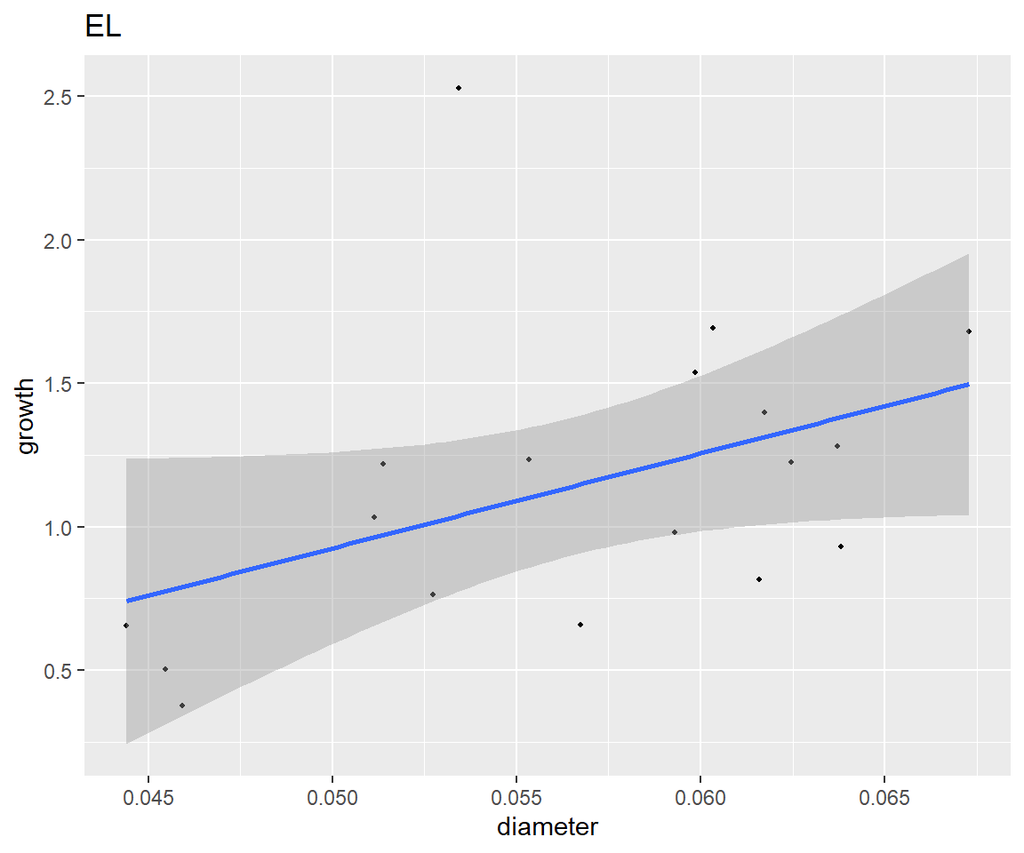

```r
primary %>%
  ggplot(aes(x=diameter,y=growth))+
  geom_point(size=0.8)+
  geom_smooth(method = "lm")+
  labs(title='EL')
```

### 5.2.2 Modèle

```r
mod_EL <- lm(growth~diameter, data=primary)
pander(summary(mod_EL))
```

|  | Estimate | Std. Error | t value | Pr(>\|t\|) |
| --- | --- | --- | --- | --- |
| **(Intercept)** | -0.7258 | 0.9639 | -0.753 | 0.4624 |
| **diameter** | 33.03 | 16.95 | 1.949 | 0.06904 |

Fitting linear model: growth ~ diameter

| Observations | Residual Std. Error | $R^2$ | Adjusted $R^2$ |
| --- | --- | --- | --- |
| 18 | 0.4806 | 0.1919 | 0.1414 |

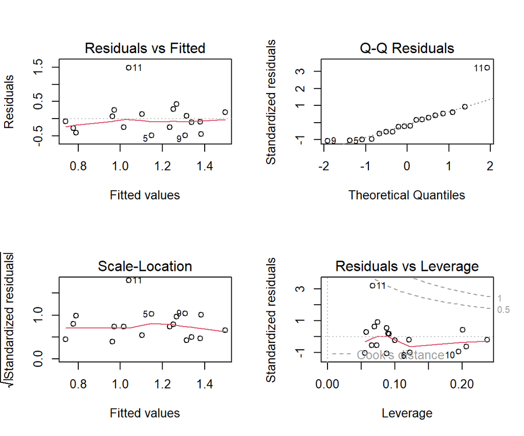

```r
par(mfrow=c(2,2))
plot(mod_EL)
```

```r
par(mfrow=c(1,1))
```

## 5.3 maxAdv

```r
maxAdv <- node %>%
  group_by(plant) %>% summarise_if(is.numeric,sum)

pander(maxAdv %>%
  select('plant','number'))
```

| plant | number |
| --- | --- |
| A1 | 37 |
| A2 | 32 |
| A3 | 24 |
| B1 | 28 |
| B2 | 28 |
| B3 | 28 |
| H1 | 35 |
| H2 | 25 |
| H3 | 30 |
| J1 | 45 |
| J2 | 29 |
| J3 | 32 |
| S1 | 25 |
| S2 | 27 |
| S3 | 32 |
| V1 | 30 |
| V2 | 28 |
| V3 | 25 |

## 5.4 dADV

```r
paste('La moyenne des diamètres de racines nodales pour les six variétés est de',
      mean(nodal_clean$diameter*10),
      '[mm]')
```

```
## [1] "La moyenne des diamètres de racines nodales pour les six variétés est de 2.37951166792176 [mm]"
```

```r
paste('dAdv = 2.3795/dMax =',
      mean(nodal_clean$diameter*10)/Dmax)
```

```
## [1] "dAdv = 2.3795/dMax = 0.340682806594304"
```

## 5.5 dSem

```r
paste('La moyenne des diamètres de racines primaire pour les six variétés est de',
      mean(primary$diameter*10),
      '[mm]')
```

```
## [1] "La moyenne des diamètres de racines primaire pour les six variétés est de 0.564806791111111 [mm]"
```

```r
paste('dSem = 0.5648/dMax =',
      mean(primary$diameter*10)/Dmax)
```

```
## [1] "dSem = 0.5648/dMax = 0.0808653159273279"
```

# 6 Annexe

## 6.1 Nombre de racine nodale par noeud

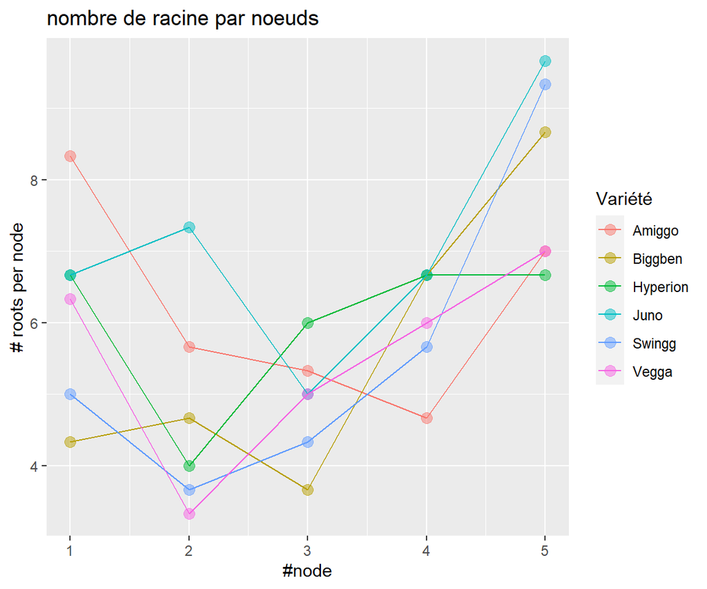

```r
#PLot
ggplot(aggregate(number ~variety+node,data = node,FUN=mean),aes(x=node,y=number,color=variety)) +
  geom_point(alpha = 0.5, size=3) +
  geom_line()+
  labs(color = "Variété",
       x= "#node",
       y= "# roots per node",
       title = "nombre de racine par noeuds")
```

```r
#Table
pander(left_join(
  node %>% group_by(variety, node) %>% summarize(mean = mean(number)),
  node %>% group_by(variety, node) %>% summarize(sd = sd(number))
))
```

| variety | node | mean | sd |
| --- | --- | --- | --- |
| Amiggo | 1 | 8.333 | 4.041 |
| Amiggo | 2 | 5.667 | 0.5774 |
| Amiggo | 3 | 5.333 | 0.5774 |
| Amiggo | 4 | 4.667 | 2.082 |
| Amiggo | 5 | 7 | 1 |
| Biggben | 1 | 4.333 | 1.528 |
| Biggben | 2 | 4.667 | 1.528 |
| Biggben | 3 | 3.667 | 0.5774 |
| Biggben | 4 | 6.667 | 0.5774 |
| Biggben | 5 | 8.667 | 1.155 |
| Hyperion | 1 | 6.667 | 1.155 |
| Hyperion | 2 | 4 | 1.732 |
| Hyperion | 3 | 6 | 3.464 |
| Hyperion | 4 | 6.667 | 0.5774 |
| Hyperion | 5 | 6.667 | 0.5774 |
| Juno | 1 | 6.667 | 1.528 |
| Juno | 2 | 7.333 | 2.517 |
| Juno | 3 | 5 | 1.732 |
| Juno | 4 | 6.667 | 1.155 |
| Juno | 5 | 9.667 | 2.082 |
| Swingg | 1 | 5 | 1 |
| Swingg | 2 | 3.667 | 0.5774 |
| Swingg | 3 | 4.333 | 0.5774 |
| Swingg | 4 | 5.667 | 2.309 |
| Swingg | 5 | 9.333 | 1.528 |
| Vegga | 1 | 6.333 | 3.055 |
| Vegga | 2 | 3.333 | 0.5774 |
| Vegga | 3 | 5 | 1 |
| Vegga | 4 | 6 | 0 |
| Vegga | 5 | 7 | 1 |

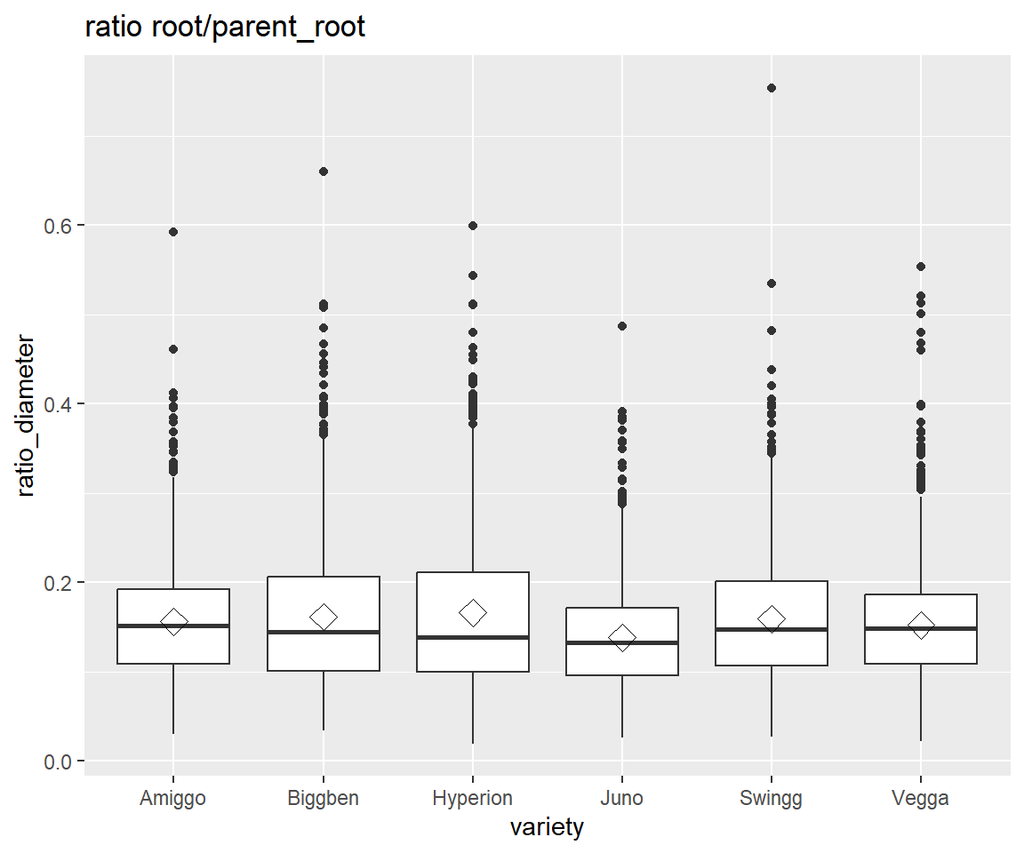

```r
subset(end.data,root_ontology==' Lateral root') %>%
  diameter_outliers(.) %>%
  ggplot(aes(x=variety,y=ratio_diameter))+
  geom_boxplot()+
  stat_summary(fun=mean, geom="point", shape=23, size=4)+
  labs(title='ratio root/parent_root')+
  theme_gray()
```